# Clustering Employees to Lower Turnover

Ricky Soo

January 7th, 2021

This is a mini data science project in collaboration with Lim Lee Wen based on the Human Resources Data Set by Dr. Rich at https://www.kaggle.com/rhuebner/human-resources-data-set

## Introduction

To reduce loss of talent, the HR department can seek to understand the active employees by segmenting them into different groups. The member of each group is similar with one another, yet are dissimilar with members from other groups. By doing so, the company can gain insights into how the employees are similar and different from one another, and devise strategies in dealing with them.

```r
library(gower)
library(factoextra)
library(cluster)
library(clustertend)
library(dplyr)
# Make model repeatable
set.seed(315)

# Load data and select only active employees
df_active <- readRDS('HRDataset_v14-cleaned.rds') %>%
  filter(
    Termd == 0
  )

row.names(df_active) <- df_active$EmpID

str(df_active)
```

```
## 'data.frame':    207 obs. of  38 variables:
##  $ Employee_Name             : chr  "Adinolfi, Wilson  K" "Alagbe,Trina" "Anderson, Linda  " "Andreola, Colby" ...
##  $ EmpID                     : chr  "10026" "10088" "10002" "10194" ...
##  $ MarriedID                 : int  0 1 0 0 0 0 0 0 0 1 ...
##  $ MaritalStatusID           : int  0 1 0 0 4 0 2 2 0 1 ...
##  $ GenderID                  : int  1 0 0 0 1 0 1 1 1 0 ...
##  $ EmpStatusID               : int  1 1 1 1 1 3 1 1 1 2 ...
##  $ DeptID                    : int  5 5 5 4 5 5 3 3 5 5 ...
##  $ PerfScoreID               : int  4 3 4 3 3 3 3 4 3 4 ...
##  $ FromDiversityJobFairID    : int  0 0 0 0 0 1 0 1 0 0 ...
##  $ Salary                    : int  62506 64991 57568 95660 59365 47837 50178 92328 58709 70131 ...
##  $ Termd                     : int  0 0 0 0 0 0 0 0 0 0 ...
##  $ PositionID                : int  19 19 19 24 19 19 14 9 19 20 ...
##  $ Position                  : Factor w/ 29 levels "Accountant I",..: 20 20 20 25 20 20 15 7 20 21 ...
##  $ State                     : Factor w/ 28 levels "AL","AZ","CA",..: 11 11 11 11 11 11 11 24 11 11 ...
```

[output cut: 24 more lines]

```r
head(df_active)
```

```
##             Employee_Name EmpID MarriedID MaritalStatusID GenderID EmpStatusID
## 10026 Adinolfi, Wilson  K 10026         0               0        1           1
## 10088        Alagbe,Trina 10088         1               1        0           1
## 10002   Anderson, Linda   10002         0               0        0           1
## 10194     Andreola, Colby 10194         0               0        0           1
## 10062         Athwal, Sam 10062         0               4        1           1
## 10114    Bachiochi, Linda 10114         0               0        0           3
##       DeptID PerfScoreID FromDiversityJobFairID Salary Termd PositionID
## 10026      5           4                      0  62506     0         19
## 10088      5           3                      0  64991     0         19
## 10002      5           4                      0  57568     0         19
## 10194      4           3                      0  95660     0         24
## 10062      5           3                      0  59365     0         19
## 10114      5           3                      1  47837     0         19
##                      Position State  Zip        DOB Sex MaritalDesc CitizenDesc
```

[output cut: 41 more lines]

## Data Preparation

Select the variables and scale the numeric variables for clustering. The salary variable is log-transformed as it is highly skewed.

```r
df_scaled <- as.data.frame(df_active)
df_scaled$Salary <- log10(df_scaled$Salary)

df_scaled <- df_scaled %>%
  dplyr::select(
    Salary,
    Position,
    State,
    Sex,
    MaritalDesc,
    CitizenDesc,
    HispanicLatino,
    RaceDesc,
    Department,
    ManagerName,
    RecruitmentSource,
    PerformanceScore,
    EngagementSurvey,
    EmpSatisfaction,
    SpecialProjectsCount,
    DaysLateLast30,
    Absences,
    TempAge,
    TempYrOfService
  )

num_cols <- colnames(df_scaled)[unlist(sapply(df_scaled, is.numeric))]
df_scaled[num_cols] <- sapply(df_scaled[num_cols], scale)

str(df_scaled)
```

```
## 'data.frame':    207 obs. of  19 variables:
##  $ Salary              : num  -0.254 -0.119 -0.539 1.219 -0.433 ...
##  $ Position            : Factor w/ 29 levels "Accountant I",..: 20 20 20 25 20 20 15 7 20 21 ...
##  $ State               : Factor w/ 28 levels "AL","AZ","CA",..: 11 11 11 11 11 11 11 24 11 11 ...
##  $ Sex                 : Factor w/ 2 levels "F","M ": 2 1 1 1 2 1 2 2 2 1 ...
##  $ MaritalDesc         : Factor w/ 5 levels "Divorced","Married",..: 4 2 4 4 5 4 1 1 4 2 ...
##  $ CitizenDesc         : Factor w/ 3 levels "Eligible NonCitizen",..: 3 3 3 3 3 3 3 3 3 3 ...
##  $ HispanicLatino      : Factor w/ 2 levels "No","Yes": 1 1 1 1 1 1 1 1 1 1 ...
##  $ RaceDesc            : Factor w/ 6 levels "American Indian or Alaska Native",..: 6 6 6 6 6 3 6 3 5 6 ...
##  $ Department          : Factor w/ 6 levels "Admin Offices",..: 4 4 4 6 4 4 3 3 4 4 ...
##  $ ManagerName         : Factor w/ 21 levels "Alex Sweetwater",..: 18 9 2 1 15 5 19 20 14 14 ...
##  $ RecruitmentSource   : Factor w/ 9 levels "CareerBuilder",..: 6 5 6 6 3 2 5 2 4 3 ...
##  $ PerformanceScore    : Factor w/ 4 levels "Exceeds","Fully Meets",..: 1 2 1 2 2 2 2 1 2 1 ...
##  $ EngagementSurvey    : num  0.615 0.922 1.126 -1.382 1.126 ...
##  $ EmpSatisfaction     : Factor w/ 5 levels "1","2","3","4",..: 5 5 5 3 4 3 5 4 4 3 ...
##  $ SpecialProjectsCount: num  -0.578 -0.578 -0.578 1.001 -0.578 ...
##  $ DaysLateLast30      : num  -0.274 -0.274 -0.274 -0.274 -0.274 ...
##  $ Absences            : num  -1.51 0.884 0.884 1.568 1.568 ...
##  $ TempAge             : num  -0.5059 -1.1009 0.3271 0.0891 -0.3869 ...
##  $ TempYrOfService     : num  0.865 2.901 0.865 -0.661 -0.152 ...
```

```r
head(df_scaled)
```

```
##           Salary                Position State Sex MaritalDesc CitizenDesc
## 10026 -0.2541211 Production Technician I    MA  M       Single  US Citizen
## 10088 -0.1191572 Production Technician I    MA   F     Married  US Citizen
## 10002 -0.5390151 Production Technician I    MA   F      Single  US Citizen
## 10194  1.2190195       Software Engineer    MA   F      Single  US Citizen
## 10062 -0.4326054 Production Technician I    MA  M      Widowed  US Citizen
## 10114 -1.1800341 Production Technician I    MA   F      Single  US Citizen
##       HispanicLatino                  RaceDesc           Department
## 10026             No                     White    Production
## 10088             No                     White    Production
## 10002             No                     White    Production
## 10194             No                     White Software Engineering
## 10062             No                     White    Production
## 10114             No Black or African American    Production
##           ManagerName  RecruitmentSource PerformanceScore EngagementSurvey
```

[output cut: 20 more lines]

```r
# Confirm there is no missing value
sum(is.na(df_scaled))
```

```
## [1] 0
```

## Gower Distance

The dissimilarity matrix is first generated using the Gower distance. Gower is used as we are dealing with mixed data types rather than just numeric variables, where Euclidean or Manhattan distance would be useful.

```r
dist <- matrix(0, ncol = nrow(df_scaled))
dist <- as.data.frame(dist)

for (i in 1:nrow(df_scaled)) {
  dist[i, ] <- gower_dist(df_scaled[i, ], df_scaled)
}

saveRDS(dist, 'dist.rds')
dist_mat <- as.matrix(dist)
```

## Clustering Tendency

The Hopkins statistic (Lawson and Jurs, 1990) and data visualization are used to assess whether the distance matrix is feasible for cluster analysis. If the Hopkins statistic is close to 0.5, or the data visualization shows random distribution of blue color, then there is no meaningful clusters.

The Hopkins statistic measures the probability that the data is generated by a uniform data distribution. In this case, the data is shown to be cohesive enough for clustering.

```r
hopkins(dist_mat, n = nrow(dist_mat) - 1)
```

```
## $H
## [1] 0.196678
```

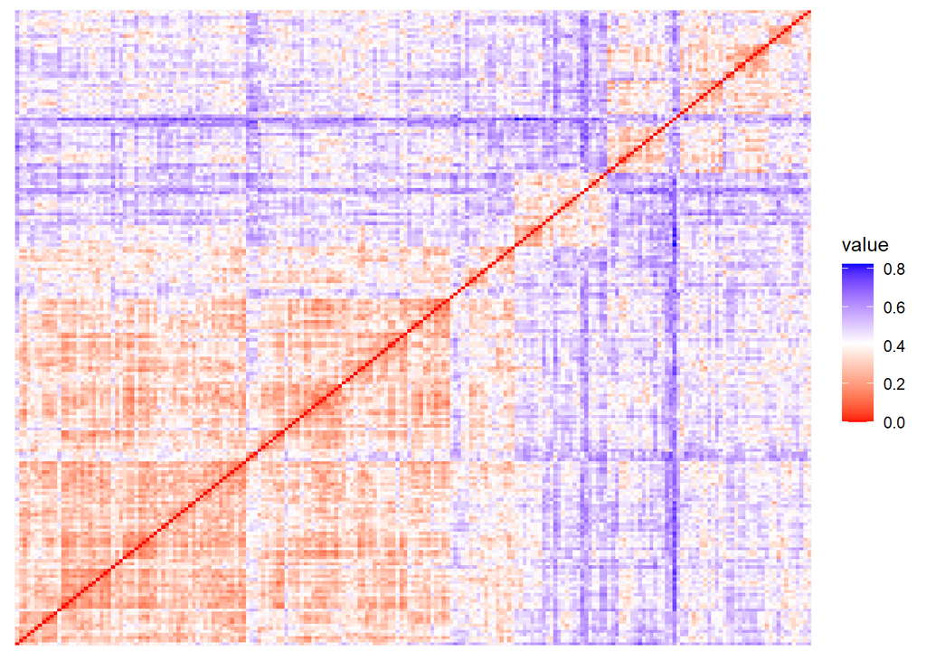

```r
fviz_dist(as.dist(dist), show_labels = FALSE)
```

## Optimum Number of Clusters

3 methods are used to find the best number of clusters - Silhouette, Elbow method (within-cluster sum of square of WSS), and the Gap Statistic.

In this case, the Silhouette method suggests 2 clusters. The Elbow method suggest 3 clusters. The Gap Statistic suggests 4 clusters. A middle ground of 3 clusters is chosen as it fares well enough in all methods.

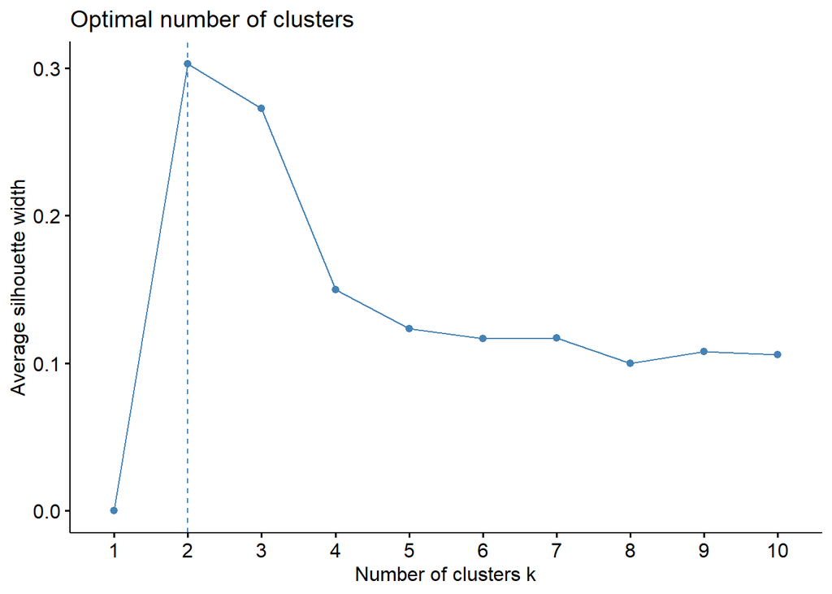

```r
fviz_nbclust(dist_mat, pam, method = 'silhouette')
```

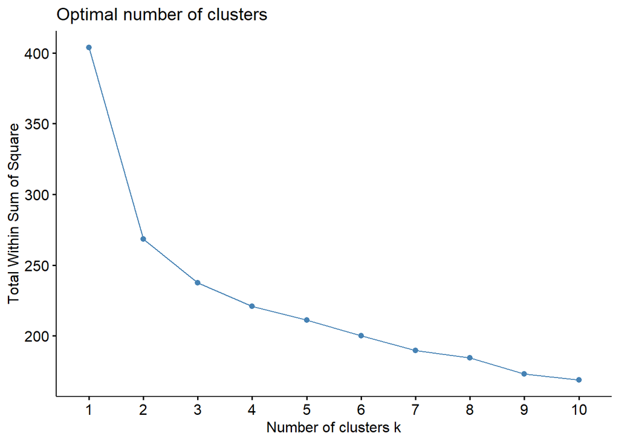

```r
fviz_nbclust(dist_mat, pam, method = 'wss')
```

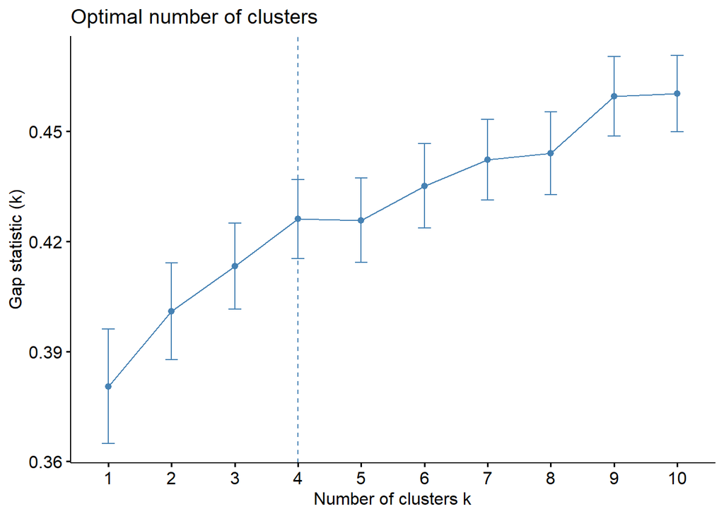

```r
fviz_nbclust(dist_mat, pam, method = 'gap_stat')
```

## Clustering Using PAM

Then the data is clustered into 3 clusters using Partitioning Around Medoids (PAM). It is a k-medoids algorithm in which data points are clustered around middle data point of each cluster, rather than mean value as in k-means algorithm.

The PAM algorithm is more robust to noise and less sensitive to outliers than k-means algorithm.

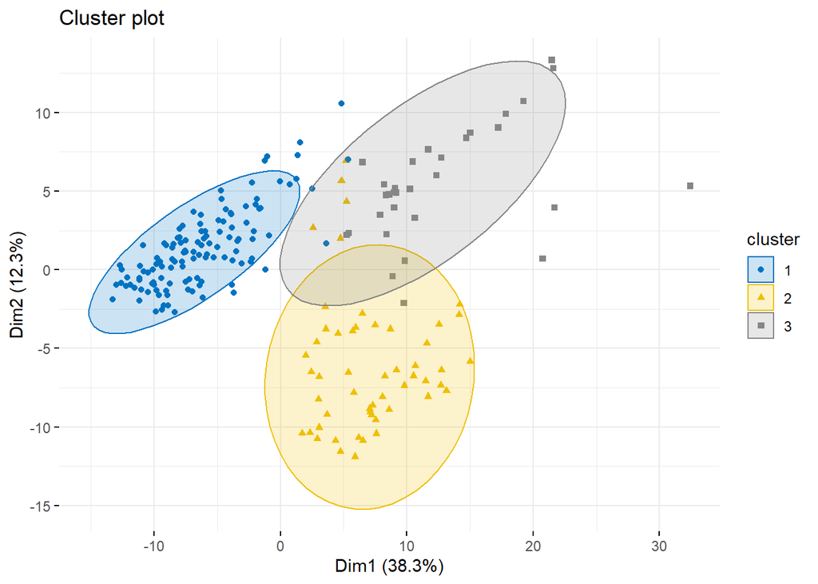

```r
pam.res <- pam(dist_mat, k = 3)

fviz_cluster(
  pam.res,
  data = df_scaled,
  palette = 'jco',
  ellipse.type = 't',
  geom = 'point',
  start.plot = TRUE,
  repel = TRUE,
  ggtheme = theme_minimal()
)
```

```r
saveRDS(pam.res, 'pam.rds')
```

## Evaluation of Clusters

The generated clusters are then evaluated using the Silhouette width method. It shows that the data points are well clustered with just a few data points showing negative Silhoutte widths.

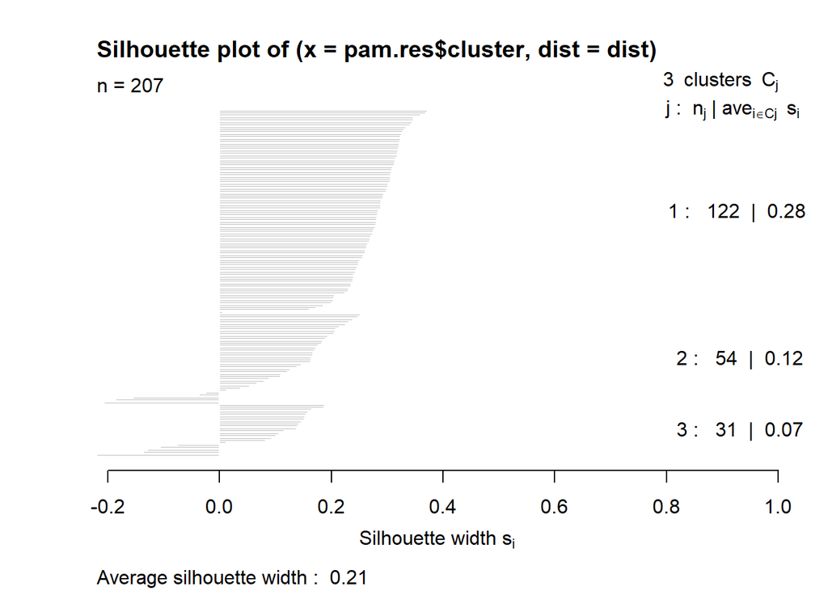

```r
sil <- silhouette(pam.res$cluster, dist)
plot(sil)
```

```
##   cluster size ave.sil.width
## 1       1  122          0.33
## 2       2   54          0.22
## 3       3   31          0.14
```

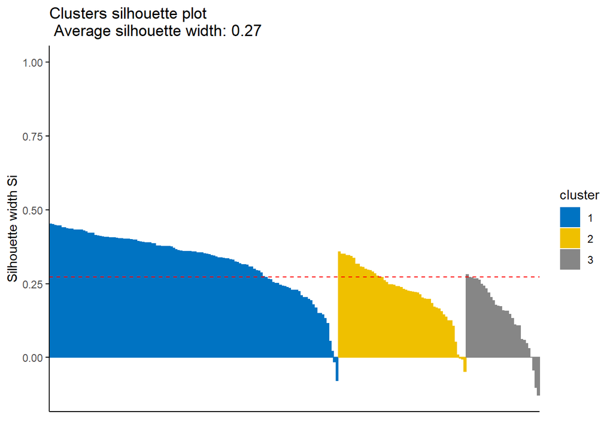

```r
fviz_silhouette(pam.res, palette = 'jco', ggtheme = theme_classic())
```

```r
sil[sil[, 'sil_width'] < 0, ]
```

```
##       cluster neighbor   sil_width
##  [1,]       3        2 -0.11622271
##  [2,]       3        2 -0.13619274
##  [3,]       3        1 -0.22002013
##  [4,]       2        1 -0.12499086
##  [5,]       2        1 -0.20620159
##  [6,]       2        1 -0.18638566
##  [7,]       2        1 -0.02514931
##  [8,]       3        1 -0.06906233
##  [9,]       2        3 -0.18589211
## [10,]       3        1 -0.14614078
## [11,]       3        2 -0.10678000
## [12,]       2        1 -0.03695352
## [13,]       3        2 -0.07534500
## [14,]       2        1 -0.15527599
## [15,]       3        2 -0.12992515
```

## Adding Cluster Info

The cluster number of each employee is then added back to the dataset. The means of each numeric variable is calculated to give an initial assessment of the resulting clusters.

```r
df_clustered <- cbind(Cluster = pam.res$cluster, df_active)
df_clustered$Cluster <- as.factor(df_clustered$Cluster)
head(df_clustered)
```

```
##   Cluster       Employee_Name EmpID MarriedID MaritalStatusID GenderID
## 1       1 Adinolfi, Wilson  K 10026         0               0        1
## 2       1        Alagbe,Trina 10088         1               1        0
## 3       1   Anderson, Linda   10002         0               0        0
## 4       2     Andreola, Colby 10194         0               0        0
## 5       1         Athwal, Sam 10062         0               4        1
## 6       1    Bachiochi, Linda 10114         0               0        0
##   EmpStatusID DeptID PerfScoreID FromDiversityJobFairID Salary Termd PositionID
## 1           1      5           4                      0  62506     0         19
## 2           1      5           3                      0  64991     0         19
## 3           1      5           4                      0  57568     0         19
## 4           1      4           3                      0  95660     0         24
## 5           1      5           3                      0  59365     0         19
## 6           3      5           3                      1  47837     0         19
##                  Position State  Zip        DOB Sex MaritalDesc CitizenDesc
```

[output cut: 41 more lines]

```r
saveRDS(df_clustered, 'HRDataset_v14-clustered.rds')
```

```r
# Show info of the medoids of each cluster
pam.res$clusinfo
```

```
##      size max_diss  av_diss diameter separation
## [1,]  122 2.011804 1.229564 2.583674  0.8256592
## [2,]   54 1.953180 1.293951 2.361562  0.6966623
## [3,]   31 2.848821 1.404985 3.787515  0.6966623
```

```r
df_clustered[pam.res$id.med, ]
```

```
##     Cluster      Employee_Name EmpID MarriedID MaritalStatusID GenderID
## 163       1     Rose, Ashley   10054         0               3        0
## 7         2 Bacong, Alejandro  10250         0               2        1
## 118       3   Leruth, Giovanni 10103         0               3        1
##     EmpStatusID DeptID PerfScoreID FromDiversityJobFairID Salary Termd
## 163           1      5           3                      0  60627     0
## 7             1      3           3                      0  50178     0
## 118           1      6           3                      0  70468     0
##     PositionID                Position State   Zip        DOB Sex MaritalDesc
## 163         19 Production Technician I    MA  1886 1974-12-05   F   Separated
## 7           14              IT Support    MA  1886 1988-01-07  M     Divorced
## 118          3      Area Sales Manager    UT 84111 1988-12-27  M    Separated
##     CitizenDesc HispanicLatino                  RaceDesc DateofHire
## 163  US Citizen             No                     White 2014-01-06
## 7    US Citizen             No                     White 2015-01-05
```

[output cut: 17 more lines]

```r
# Show the means of numeric variables of each cluster
aggregate(df_active[, num_cols], by = list(CLUSTER = pam.res$cluster), mean)
```

```
##   CLUSTER   Salary EngagementSurvey SpecialProjectsCount DaysLateLast30
## 1       1 59336.82         4.199836           0.03278689      0.2049180
## 2       2 92270.85         4.061111           5.05555556      0.2407407
## 3       3 77804.74         3.907097           0.83870968      0.7096774
##    Absences  TempAge TempYrOfService
## 1  9.475410 41.55738        7.442623
## 2  9.833333 40.53704        6.500000
## 3 11.225806 41.29032        8.129032
```

## Visualizing Clusters

The clusters of employees are now visualized using bar plots and histograms. Each shows what makes them different from one another.

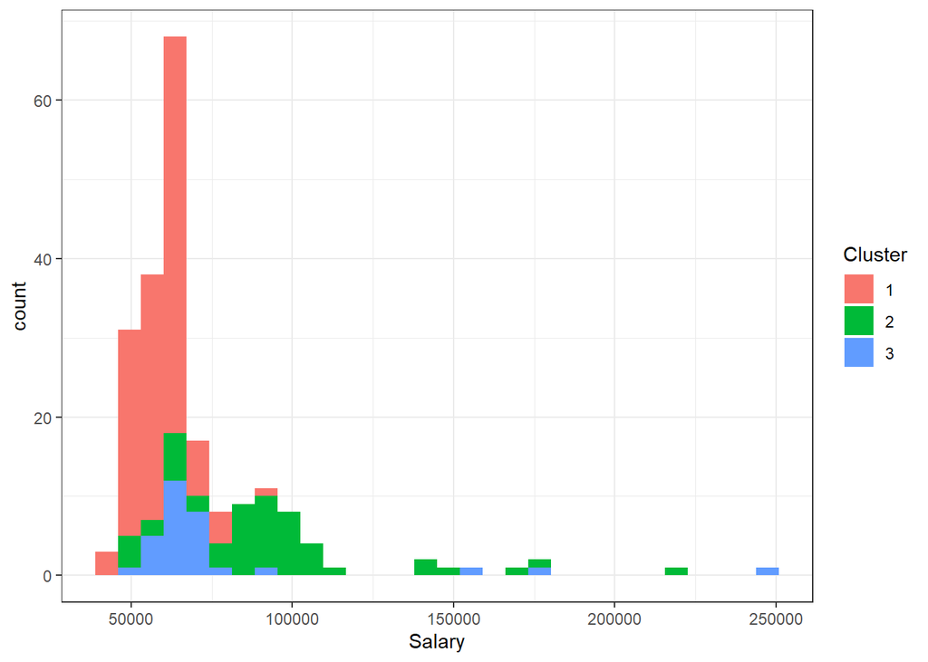

```r
theme_set(theme_bw())

ggplot(data = df_clustered, aes(x = Salary, fill = Cluster)) +
  geom_histogram()
```

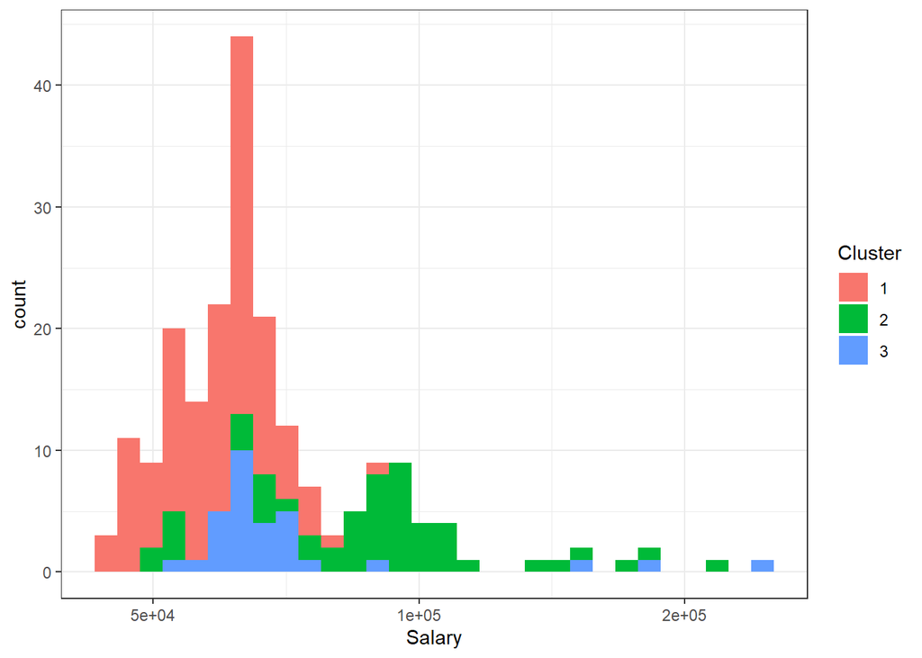

```r
ggplot(data = df_clustered, aes(x = Salary, fill = Cluster)) +
  geom_histogram() +
  scale_x_log10()
```

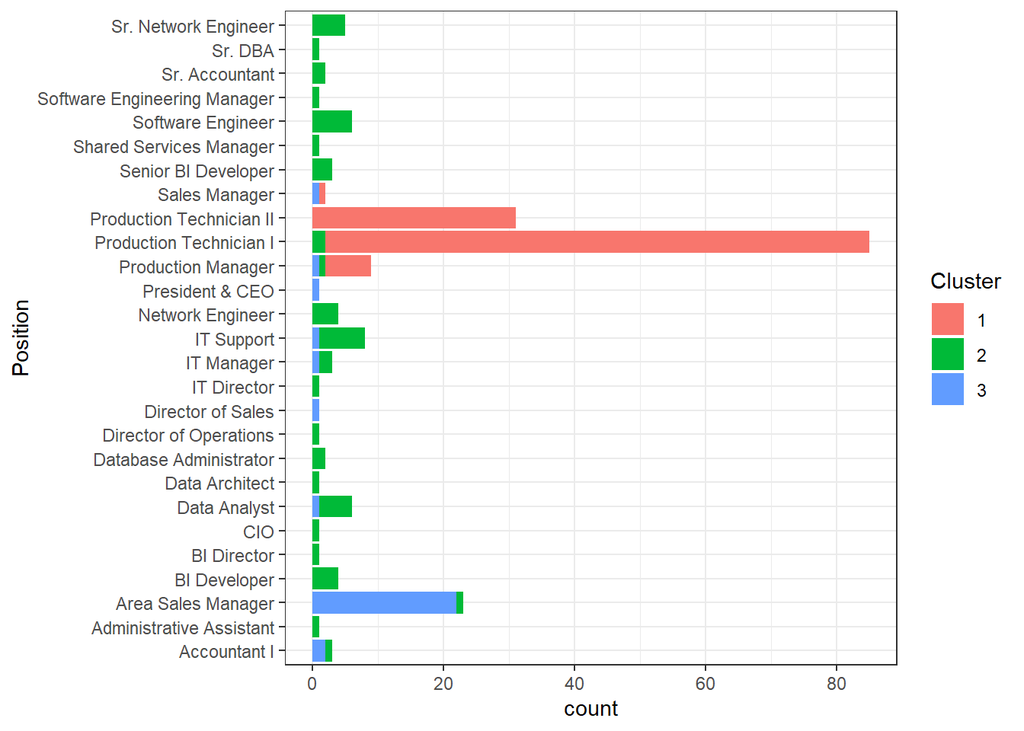

```r
ggplot(data = df_clustered, aes(y = Position, fill = Cluster)) +
  geom_bar()
```

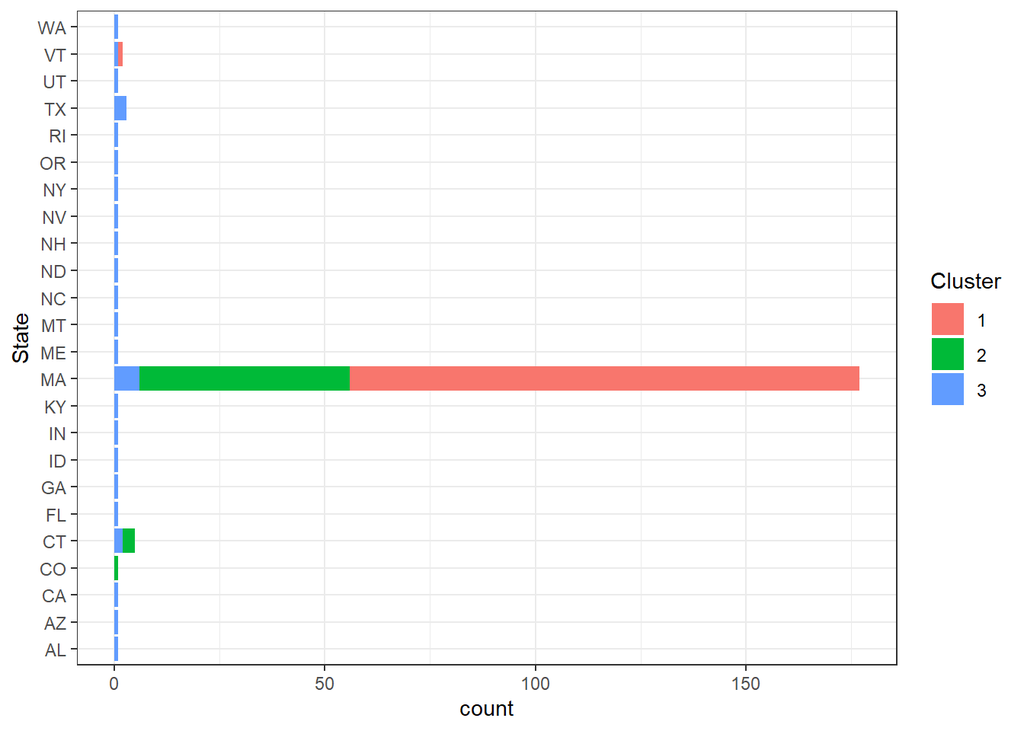

```r
ggplot(data = df_clustered, aes(y = State, fill = Cluster)) +
  geom_bar()
```

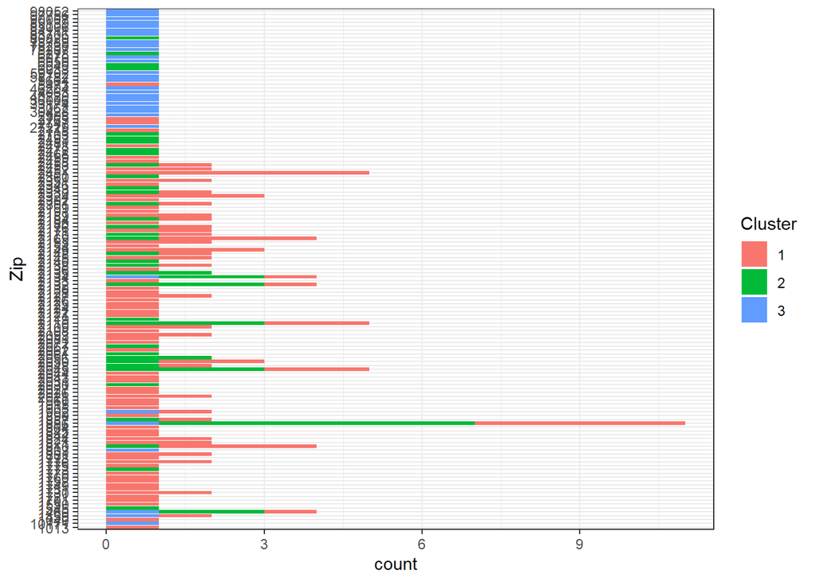

```r
ggplot(data = df_clustered, aes(y = Zip, fill = Cluster)) +
  geom_bar()
```

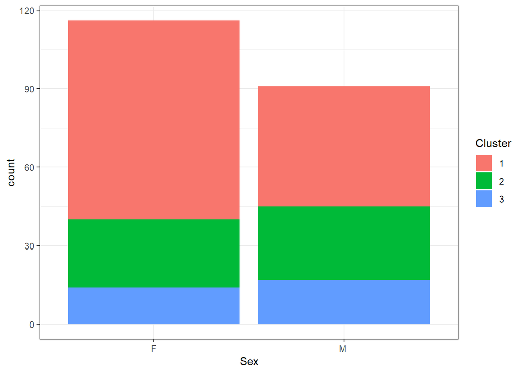

```r
ggplot(data = df_clustered, aes(x = Sex, fill = Cluster)) +
  geom_bar()
```

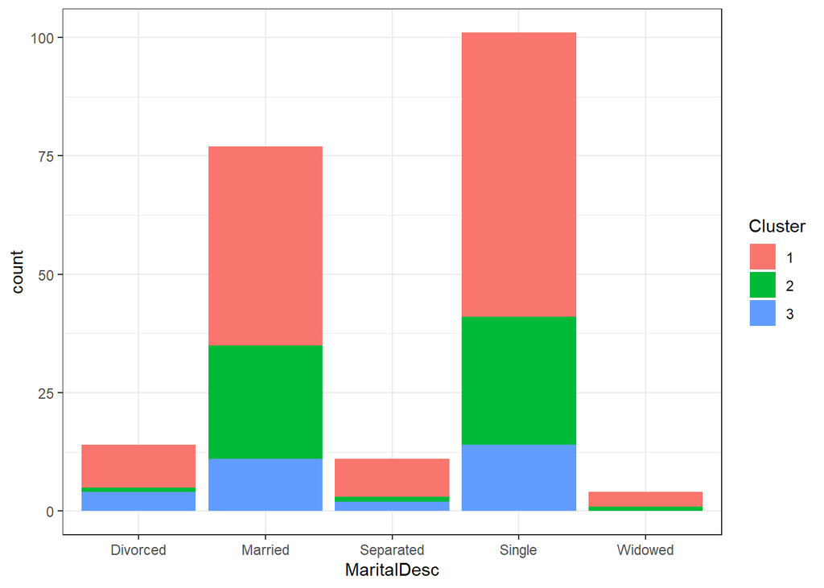

```r
ggplot(data = df_clustered, aes(x = MaritalDesc, fill = Cluster)) +
  geom_bar()
```

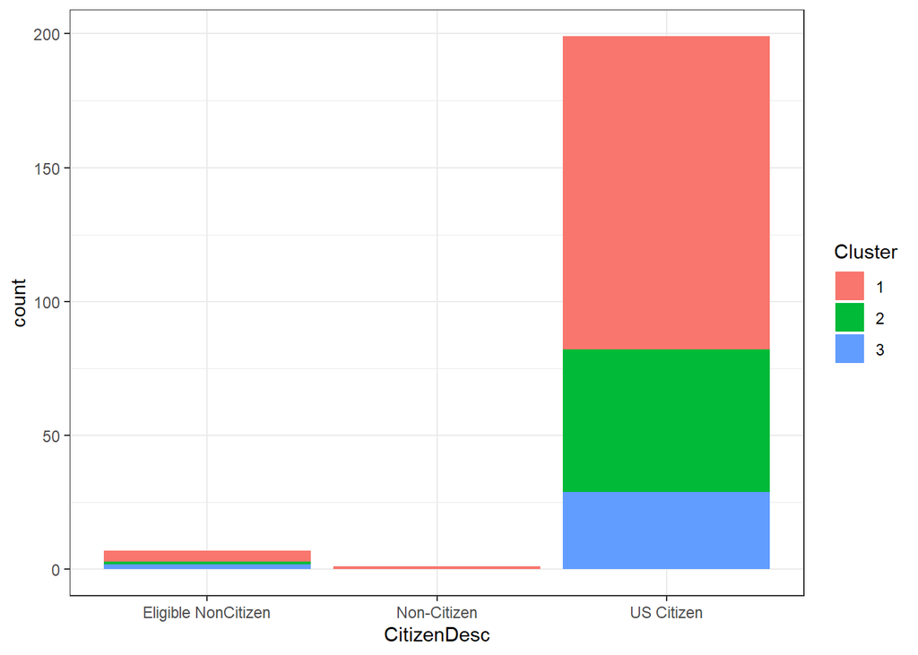

```r
ggplot(data = df_clustered, aes(x = CitizenDesc, fill = Cluster)) +
  geom_bar()
```

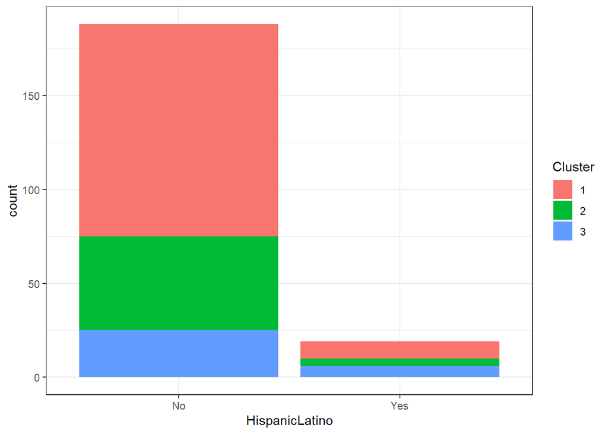

```r
ggplot(data = df_clustered, aes(x = HispanicLatino, fill = Cluster)) +
  geom_bar()
```

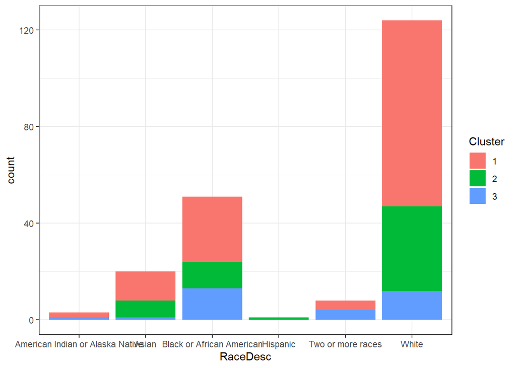

```r
ggplot(data = df_clustered, aes(x = RaceDesc, fill = Cluster)) +
  geom_bar()
```

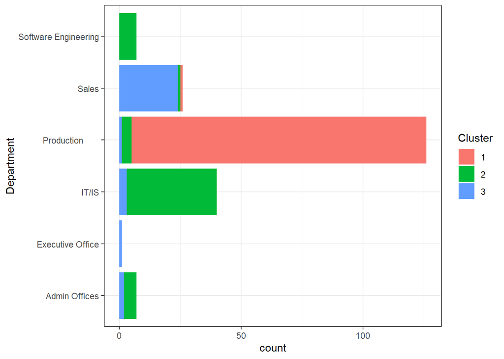

```r
ggplot(data = df_clustered, aes(y = Department, fill = Cluster)) +
  geom_bar()
```

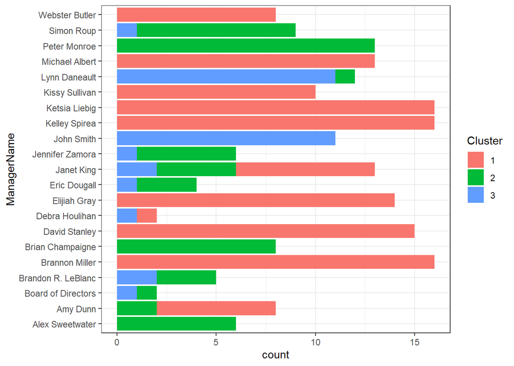

```r
ggplot(data = df_clustered, aes(y = ManagerName, fill = Cluster)) +
  geom_bar()
```

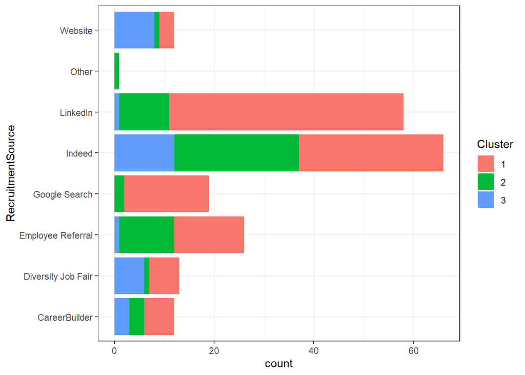

```r
ggplot(data = df_clustered, aes(y = RecruitmentSource, fill = Cluster)) +
  geom_bar()
```

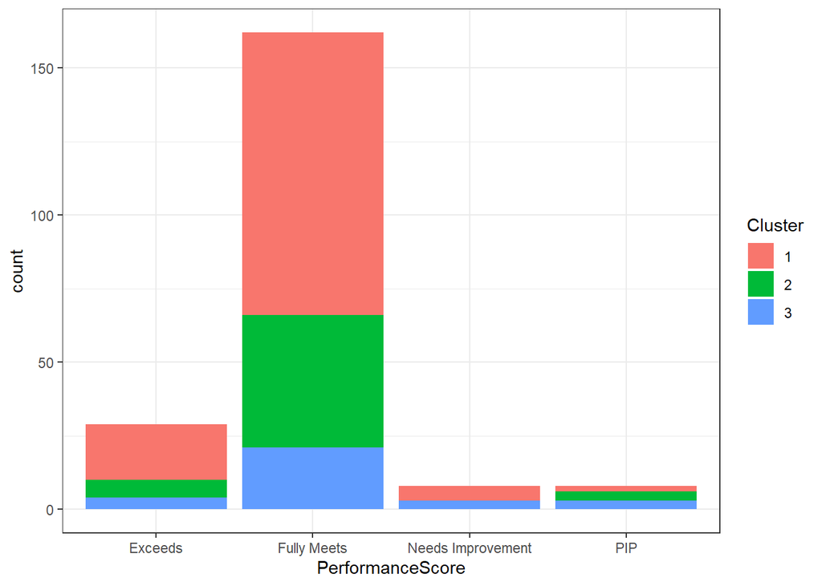

```r
ggplot(data = df_clustered, aes(x = PerformanceScore, fill = Cluster)) +
  geom_bar()
```

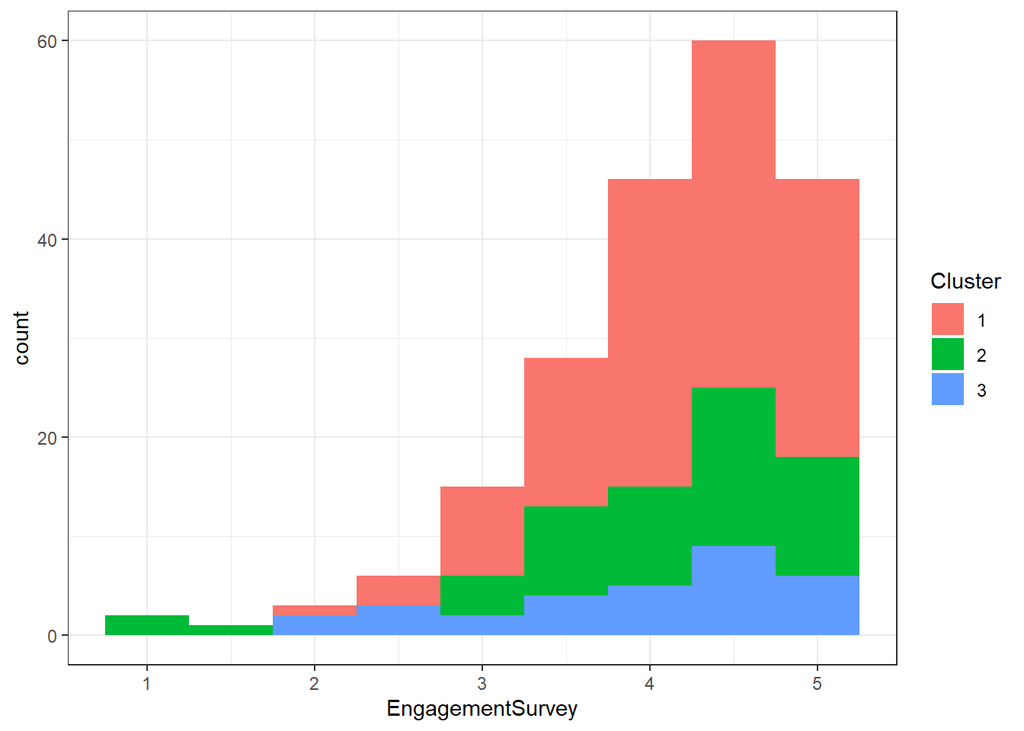

```r
ggplot(data = df_clustered, aes(x = EngagementSurvey, fill = Cluster)) +
  geom_histogram(binwidth = 0.5)
```

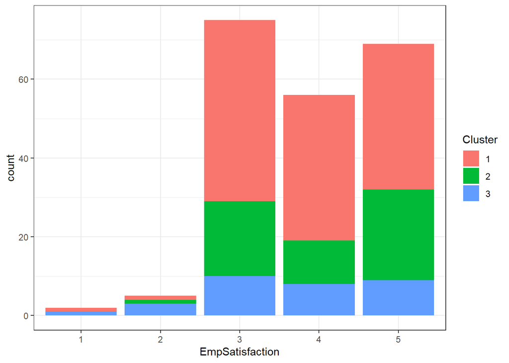

```r
ggplot(data = df_clustered, aes(x = EmpSatisfaction, fill = Cluster)) +
  geom_bar()
```

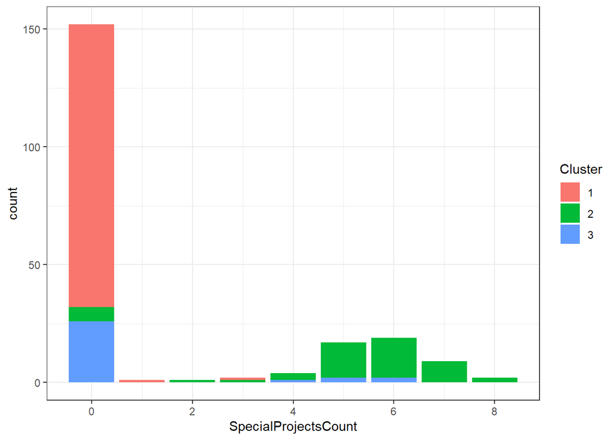

```r
ggplot(data = df_clustered, aes(x = SpecialProjectsCount, fill = Cluster)) +
  geom_bar()
```

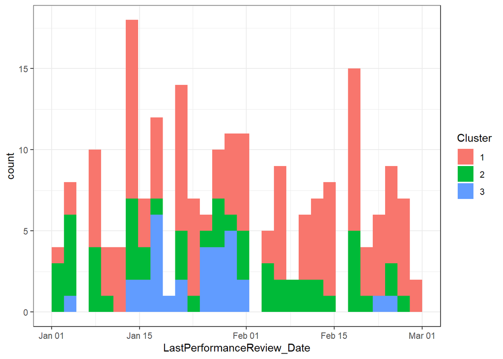

```r
ggplot(data = df_clustered, aes(x = LastPerformanceReview_Date, fill = Cluster)) +
  geom_histogram()
```

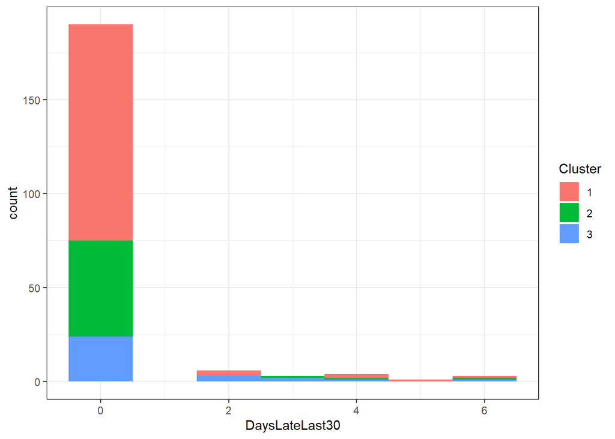

```r
ggplot(data = df_clustered, aes(x = DaysLateLast30, fill = Cluster)) +
  geom_histogram(binwidth = 1)
```

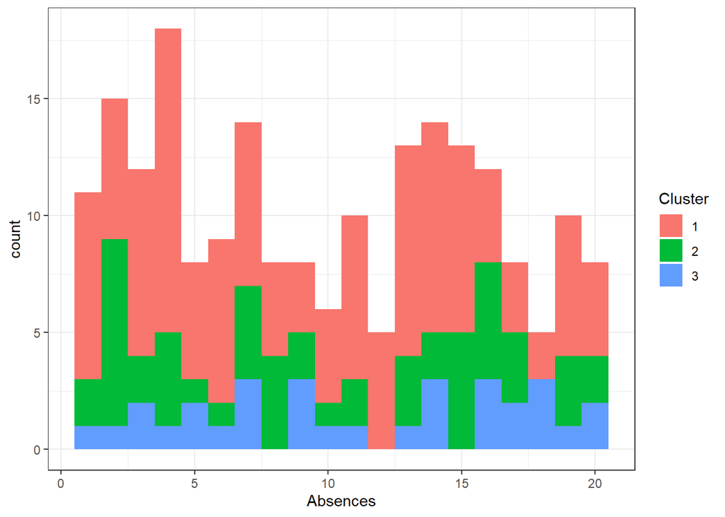

```r
ggplot(data = df_clustered, aes(x = Absences, fill = Cluster)) +
  geom_histogram(binwidth = 1)
```

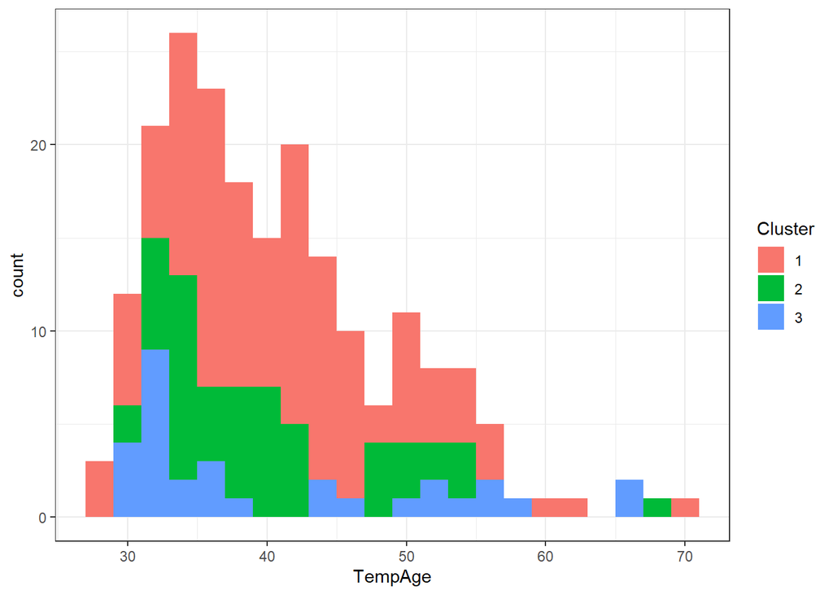

```r
ggplot(data = df_clustered, aes(x = TempAge, fill = Cluster)) +
  geom_histogram(binwidth = 2)
```

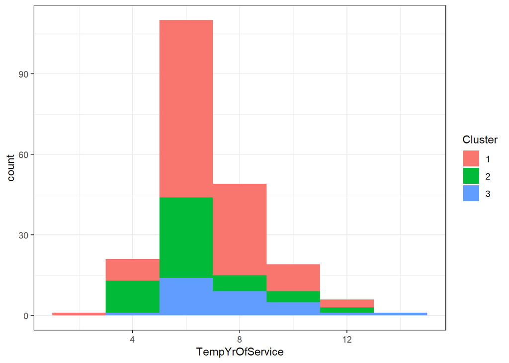

```r
ggplot(data = df_clustered, aes(x = TempYrOfService, fill = Cluster)) +
  geom_histogram(binwidth = 2)
```

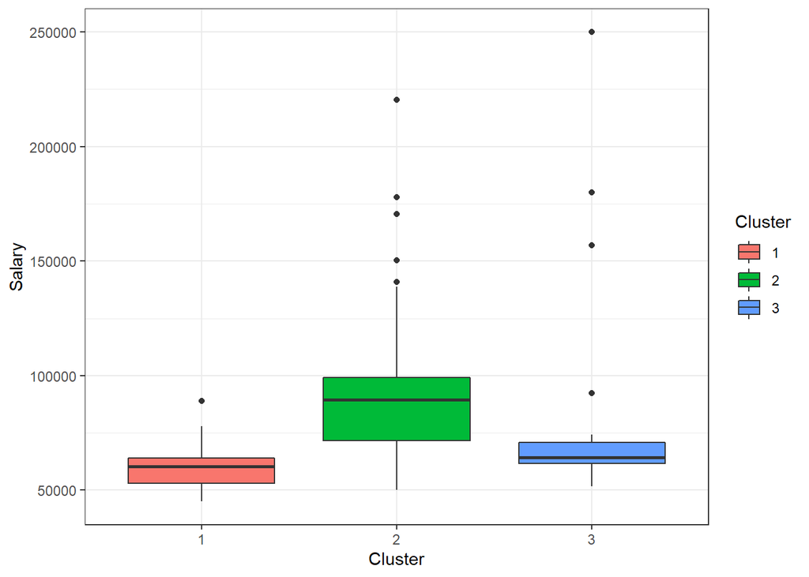

```r
ggplot(data = df_clustered, aes(x = Cluster, y = Salary, fill = Cluster)) +
  geom_boxplot()
```